# Generation of figures in report

Vigneshwari Subramanian

Attila Gabor

2018-07-19

Reproducibility of conventional and GR metrics across studies (Figure 1)

```r
library(AlternativeDrugResponseMetrics)
#Load GCSI, GDSC and CTRP data
data("GCSI_Conventional_GRMetrics_published",package = "AlternativeDrugResponseMetrics")
data("CTRP_Conventional_GRMetrics_published",package = "AlternativeDrugResponseMetrics")
data("Conventional_GR_allCalculatedMetrics_merged",package = "AlternativeDrugResponseMetrics")
data("GDSC_DrugIDs_Names_mapped",package = "AlternativeDrugResponseMetrics")

#Map GDSC Drug ids to Drug names
GDSC_DrugNames_IDs_merged<-merge(Conventional_GR_allCalculatedMetrics_merged,GDSC_DrugIDs_Names_mapped,by.x="Drug",by.y="DRUG_ID")
colnames(GDSC_DrugNames_IDs_merged)[1]="ID"
colnames(GDSC_DrugNames_IDs_merged)[20]="Drug"

GCSI_GDSC_merged<-merge(GCSI_Conventional_GRMetrics_published,GDSC_DrugNames_IDs_merged,by = c("CellLine","Drug"))
CTRP_GDSC_merged<-merge(CTRP_Conventional_GRMetrics_published,GDSC_DrugNames_IDs_merged,by=c("CellLine","Drug"))
```

GCSI and GDSC reproducibility plots

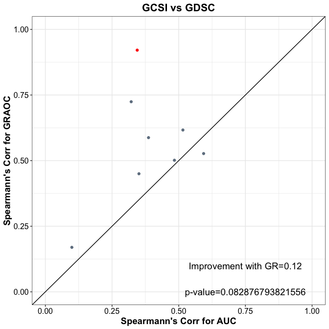

```r
library("ggplot2")

#Calculate drug-wise AUC and AOC correlations for GCSI / GDSC data and plot Drug specific AUCs and AOCs
Unique_GCSI_drugs_list<-unique(GCSI_GDSC_merged$Drug)
AllGDSCDrugs_GCSI_AUC_AOC<-c()

for(i in 1:length(Unique_GCSI_drugs_list))
{
GCSI_drug_extract<-GCSI_GDSC_merged[GCSI_GDSC_merged$Drug==Unique_GCSI_drugs_list[i],c("CellLine","GCSI_AUC","GCSI_GR_AOC","AUC","GRAOC")]

#For those drugs with multiple measurements for the same cell lines, use their average values
GCSI_drug_extract_averaged<-with(GCSI_drug_extract,aggregate(GCSI_drug_extract,by=list(CellLine=CellLine),mean))

#Consider only those cell lines that have atleast 5 cell lines with GRAOCs >0.5 as it makes more sense to compare those cell lines that are responders
GCSI_drug_extract_filtered<-GCSI_drug_extract_averaged[GCSI_drug_extract_averaged$GRAOC>0.5 & GCSI_drug_extract_averaged$GCSI_GR_AOC>0.5 ,]


if(nrow(GCSI_drug_extract_filtered)>=5)
{
GCSI_GDSC_Drug_AUC_corr<-cor(GCSI_drug_extract_averaged$GCSI_AUC,GCSI_drug_extract_averaged$AUC,method="spearman")
GCSI_GDSC_Drug_AOC_corr<-cor(GCSI_drug_extract_averaged$GCSI_GR_AOC,GCSI_drug_extract_averaged$GRAOC,method="spearman")
Drugs_AUC_AOC<-cbind.data.frame(Unique_GCSI_drugs_list[i],GCSI_GDSC_Drug_AUC_corr,GCSI_GDSC_Drug_AOC_corr)
AllGDSCDrugs_GCSI_AUC_AOC<-rbind.data.frame(AllGDSCDrugs_GCSI_AUC_AOC,Drugs_AUC_AOC)
}
}
colnames(AllGDSCDrugs_GCSI_AUC_AOC)=c("Drug","AUC","AOC")

#Compute mean differences in correlations and do a paired t-test to assess the significance of correlations after excluding the reference drug "Gemcitabine"
AllGDSCDrugs_GCSI_AUC_AOC_excludeRef<-AllGDSCDrugs_GCSI_AUC_AOC[!(AllGDSCDrugs_GCSI_AUC_AOC$Drug=="Gemcitabine"),]
AllGDSCDrugs_GCSI_AUC_AOC_Gemcitabine<-AllGDSCDrugs_GCSI_AUC_AOC[(AllGDSCDrugs_GCSI_AUC_AOC$Drug=="Gemcitabine"),]
GCSI_tTest<-(t.test(AllGDSCDrugs_GCSI_AUC_AOC_excludeRef$AUC,AllGDSCDrugs_GCSI_AUC_AOC_excludeRef$AOC,var.equal=TRUE,paired=TRUE))$p.value

Mean_correlation_diff<-mean(as.vector(AllGDSCDrugs_GCSI_AUC_AOC_excludeRef$AOC)-as.vector(AllGDSCDrugs_GCSI_AUC_AOC_excludeRef$AUC))


#Generate correlation plots
#jpeg(filename="GCSI_GDSC_AUC_AOC_correlation_plots.jpeg")
par(cex=1,mar=c(4,4,2,1),cex.lab=1,cex=1.5,font=2)
ggplot(AllGDSCDrugs_GCSI_AUC_AOC_excludeRef,aes(x=AUC,y=AOC))+geom_point(color="slategray")+geom_point(data=AllGDSCDrugs_GCSI_AUC_AOC_Gemcitabine,color="red")+geom_abline()+xlim(0,1)+ylim(0,1)+xlab("Spearmann's Corr for AUC")+ylab("Spearmann's Corr for GRAOC")+ggtitle("GCSI vs GDSC")+annotate(geom="text",label=paste("Improvement with GR=",round(Mean_correlation_diff,digits=2),sep=""),x=0.75,y=0.1,color="black",size=5)+annotate(geom="text",label=paste("p-value=",GCSI_tTest,sep=""),x=0.75,y=0,color="black",size=5)+theme_bw()+theme(plot.title = element_text(color="black",size=16,face="bold",hjust=0.5))+theme(axis.title = element_text(color="black",size=14,face="bold"))+theme(axis.text = element_text(color="black",size=12))
```

```r
#dev.off()
```

CTRP and GDSC reproducibility plots

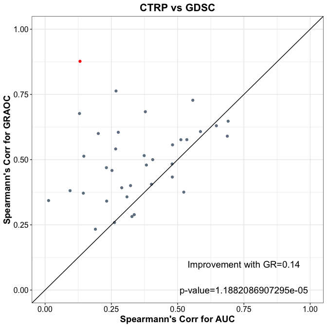

```r
library("ggplot2")

#Calculate drug-wise AUC and AOC correlations for CTRP / GDSC data and plot Drug specific AUCs and AOCs
Unique_CTRP_drugs_list<-unique(CTRP_GDSC_merged$Drug)
AllGDSCDrugs_CTRP_AUC_AOC<-c()

for(i in 1:length(Unique_CTRP_drugs_list))
{
CTRP_drug_extract<-CTRP_GDSC_merged[CTRP_GDSC_merged$Drug==Unique_CTRP_drugs_list[i],]

#For those drugs with multiple measurements for the same cell lines, use their average values
CTRP_drug_extract_averaged<-with(CTRP_drug_extract,aggregate(CTRP_drug_extract,by=list(CellLine=CellLine),mean))

#Pick up only those cell lines that have GRAOCs >0.5 as it makes more sense to compare those cell lines that are responders
CTRP_drug_extract_filtered<-CTRP_drug_extract_averaged[CTRP_drug_extract_averaged$GRAOC>0.5 & CTRP_drug_extract_averaged$CTRP_GR_AOC>0.5 ,]

#Make sure that there are atleast 5 cell lines that respond to the drug
if(nrow(CTRP_drug_extract_filtered)>=5)
{
CTRP_GDSC_Drug_AUC_corr<-cor(CTRP_drug_extract_averaged$CTRP_area_under_curve,CTRP_drug_extract_averaged$AUC,method="spearman")
CTRP_GDSC_Drug_AOC_corr<-cor(CTRP_drug_extract_averaged$CTRP_GR_AOC,CTRP_drug_extract_averaged$GRAOC,method="spearman")
Drugs_AUC_AOC<-cbind.data.frame(Unique_CTRP_drugs_list[i],CTRP_GDSC_Drug_AUC_corr,CTRP_GDSC_Drug_AOC_corr)
AllGDSCDrugs_CTRP_AUC_AOC<-rbind.data.frame(AllGDSCDrugs_CTRP_AUC_AOC,Drugs_AUC_AOC)
}
}
colnames(AllGDSCDrugs_CTRP_AUC_AOC)=c("Drug","AUC","AOC")

#Compute mean differences in correlations and do a paired t-test to assess the significance of correlations after excluding the reference drug "Gemcitabine"
AllGDSCDrugs_CTRP_AUC_AOC_excludeRef<-AllGDSCDrugs_CTRP_AUC_AOC[!(AllGDSCDrugs_CTRP_AUC_AOC$Drug=="Gemcitabine"),]
AllGDSCDrugs_CTRP_AUC_AOC_Gemcitabine<-AllGDSCDrugs_CTRP_AUC_AOC[(AllGDSCDrugs_CTRP_AUC_AOC$Drug=="Gemcitabine"),]
CTRP_tTest<-(t.test(AllGDSCDrugs_CTRP_AUC_AOC_excludeRef$AUC,AllGDSCDrugs_CTRP_AUC_AOC_excludeRef$AOC,var.equal=TRUE,paired=TRUE))$p.value

Mean_correlation_diff<-mean(as.vector(AllGDSCDrugs_CTRP_AUC_AOC_excludeRef$AOC)-as.vector(AllGDSCDrugs_CTRP_AUC_AOC_excludeRef$AUC))


#Generate correlation plots
#jpeg(filename="CTRP_GDSC_AUC_AOC_correlation_plots.jpeg")
par(cex=1,mar=c(4,4,2,1),cex.lab=1,cex=1.5,font=2)
ggplot(AllGDSCDrugs_CTRP_AUC_AOC_excludeRef,aes(x=AUC,y=AOC))+geom_point(color="slategray")+geom_point(data=AllGDSCDrugs_CTRP_AUC_AOC_Gemcitabine,color="red")+geom_abline()+xlim(0,1)+ylim(0,1)+xlab("Spearmann's Corr for AUC")+ylab("Spearmann's Corr for GRAOC")+ggtitle("CTRP vs GDSC")+annotate(geom="text",label=paste("Improvement with GR=",round(Mean_correlation_diff,digits=2),sep=""),x=0.75,y=0.1,color="black",size=5)+annotate(geom="text",label=paste("p-value=",CTRP_tTest,sep=""),x=0.75,y=0,color="black",size=5)+theme_bw()+theme(plot.title = element_text(color="black",size=16,face="bold",hjust=0.5))+theme(axis.title = element_text(color="black",size=14,face="bold"))+theme(axis.text = element_text(color="black",size=12))
```

```r
#dev.off()
```

Generate ANOVA plots (Figure 2) in the report

The preprocessing steps used for the calculation of different metrics are documented in the GDSC vignette `vignette("GDSC_Calculate_AlternativeMetrics", package = "AlternativeDrugResponseMetrics")`.

The results of the preprocessing are stored in the csv files and are further processed by GDSCTools package in Python. For details regarding ANOVA, please check the python notebook (“GDSCTools_ANOVA.ipynb”) and other files in the ANOVA folder

The results of the ANOVA analysis is loaded here and the ploting is documented below.

Load data corresponding to different metrics and obtain the p-values.

```r
library(AlternativeDrugResponseMetrics)
l <- grep("_GRset",data(package="AlternativeDrugResponseMetrics")$results[,"Item"],value = T)

pvalue_ranges<-seq(0,10,by=0.2)
Pvalues_allMetrics<-data.frame(pvalue_ranges)

allData = new.env()
data(list=l,envir = allData)


for(iMetric in ls(allData))
{
    #Extract the FDR from each of the ANOVA results file
    Allgenes_pvalues <- allData[[iMetric]]
    Allgenes_pvalues_corrected<-as.data.frame(sapply(Allgenes_pvalues$ANOVA_FEATURE_FDR, function(x) -log10(x/100)))
    p_adjusted_values_allgenes<-Allgenes_pvalues_corrected[,1]
    Allpvalues_allGenes<-c()

    for(j in 1:length(pvalue_ranges))
    {
        #Extract the number of drug gene associations for the different p value ranges
        Adjustedvalues_WithinRange_allGenes <- length( subset( p_adjusted_values_allgenes, p_adjusted_values_allgenes > pvalue_ranges[j] ))
        Allpvalues_allGenes <- c(Allpvalues_allGenes, log10(Adjustedvalues_WithinRange_allGenes))
    }
    Pvalues_allMetrics <- cbind.data.frame(Pvalues_allMetrics,as.data.frame(Allpvalues_allGenes))
}

headers_Pvalues_allMetrics<-gsub("results_","",ls(allData))
colnames(Pvalues_allMetrics)<-c("pvalue_ranges",headers_Pvalues_allMetrics)

head(Pvalues_allMetrics)
```

```
#>   pvalue_ranges Emax_GRset GDSC_AUC_GRset GDSC_LNIC50_GRset GRAOC_GRset
#> 1           0.0   4.694061       4.694895          4.694895    4.694061
#> 2           0.2   2.217484       2.925828          2.064458    2.980912
#> 3           0.4   1.892095       2.638489          1.544068    2.706718
#> 4           0.6   1.755875       2.413300          1.380211    2.541579
#> 5           0.8   1.556303       2.283301          1.176091    2.394452
#> 6           1.0   1.397940       2.173186          1.113943    2.252853
#>   GRmax_GRset LNGR50_GRset RecomputedAUC_GRset RecomputedLNIC50_GRset
#> 1    4.694061     3.680426            4.694061               3.592288
#> 2    2.747412     3.121888            2.318063               3.134496
#> 3    2.385606     2.808211            2.000000               2.910091
#> 4    2.181844     2.622214            1.755875               2.689309
#> 5    1.995635     2.503791            1.447158               2.556303
#> 6    1.851258     2.363612            1.278754               2.460898
```

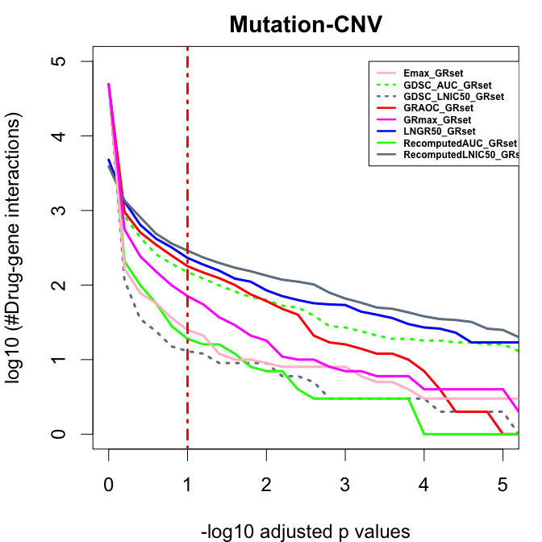

```r
#jpeg("AllANOVA_IC_GRmetrics_GRmax_Emax_plots.jpeg")
par(cex=1,mar=c(4,4,2,1),cex.lab=1,cex=1.5,font=2)

#Plot the p values against the number of drug-gene associations
plot(Pvalues_allMetrics$pvalue_ranges,Pvalues_allMetrics$GDSC_AUC,xlab="-log10 adjusted p values",ylab="log10 (#Drug-gene interactions)",main="Mutation-CNV",col="green",pch=16,type="l",lty=3,lwd=3,cex.axis=1,xlim=c(0,5),ylim=c(0,5))
points(Pvalues_allMetrics$pvalue_ranges,Pvalues_allMetrics$GDSC_LNIC50,col="slategrey",pch=16,type='l',lty=3,lwd=3,xlim=c(0,5),ylim=c(0,5))
points(Pvalues_allMetrics$pvalue_ranges,Pvalues_allMetrics$GRAOC,col="red",pch=16,type='l',lty=1,lwd=3,xlim=c(0,5),ylim=c(0,5))
points(Pvalues_allMetrics$pvalue_ranges,Pvalues_allMetrics$LNGR50,col="blue",pch=16,type='l',lty=1,lwd=3,xlim=c(0,5),ylim=c(0,5))
points(Pvalues_allMetrics$pvalue_ranges,Pvalues_allMetrics$RecomputedAUC,col="green",pch=16,type='l',lty=1,lwd=3,xlim=c(0,5),ylim=c(0,5))
points(Pvalues_allMetrics$pvalue_ranges,Pvalues_allMetrics$RecomputedLNIC50,col="slategrey",pch=16,type='l',lty=1,lwd=3,xlim=c(0,5),ylim=c(0,5))
points(Pvalues_allMetrics$pvalue_ranges,Pvalues_allMetrics$Emax,col="pink",pch=16,type='l',lty=1,lwd=3,xlim=c(0,5),ylim=c(0,5))
points(Pvalues_allMetrics$pvalue_ranges,Pvalues_allMetrics$GRmax,col="magenta",pch=16,type='l',lty=1,lwd=3,xlim=c(0,5),ylim=c(0,5))
abline (v=1,col="red",lty=4,lwd=3)
legend(3.3,5,c(headers_Pvalues_allMetrics[1],headers_Pvalues_allMetrics[2],headers_Pvalues_allMetrics[3],headers_Pvalues_allMetrics[4],headers_Pvalues_allMetrics[5],headers_Pvalues_allMetrics[6],headers_Pvalues_allMetrics[7],headers_Pvalues_allMetrics[8]),lty=c(1,3,3,1,1,1,1,1),lwd=c(2.5,2.5,2.5,2.5,2.5,2.5,2.5,2.5),cex=0.5,col=c("pink","green","slategrey","red","magenta","blue","green","slategrey"))
```

```r
#dev.off()
```

Generate venn diagrams to check for the overlap in associations between different metrics (Figure 4 and Figure 14)

Function to make venn diagrams

```r
library("VennDiagram")
```

```r
Associations_overlap<-function(Metric1,Metric2,Metric_type,Fig_FileName,col_comb)
{
  Metric1_FDR<- Metric1[Metric1$ANOVA_FEATURE_FDR<10,]
  Metric2_FDR<-Metric2[Metric2$ANOVA_FEATURE_FDR<10,]
  Metric1_Metric2_overlap<-merge(Metric1_FDR,Metric2_FDR,by=c("FEATURE","DRUG_NAME"))

  grid.newpage()
  #jpeg(Fig_FileName,quality=100)
  venn.plot<-draw.pairwise.venn(area1=nrow(Metric1_FDR),area2=nrow(Metric2_FDR), cross.area=nrow(Metric1_Metric2_overlap),category=Metric_type,fill=col_comb,cat.pos=c(180,180),fontfamily = rep("serif", 3),fontface=rep("bold",3),cat.fontfamily=rep("serif",2),cat.fontface=rep("bold",2),cex=rep(3,3),cat.cex=rep(2,2))
  grid.draw(venn.plot)
  #dev.off()
  }
```

Find the associations that overlap between AUC and GRAOC (Figure 4a)

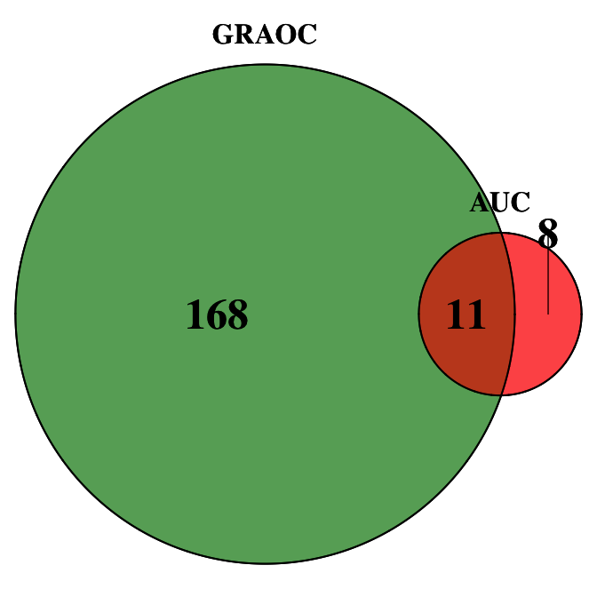

```r
Associations_overlap(results_RecomputedAUC_GRset,results_GRAOC_GRset,c("AUC","GRAOC"),"AUC_GRAOC.jpeg",c("red","forest green"))
```

Find the associations that overlap between IC50 and GR50 (Figure 4a)

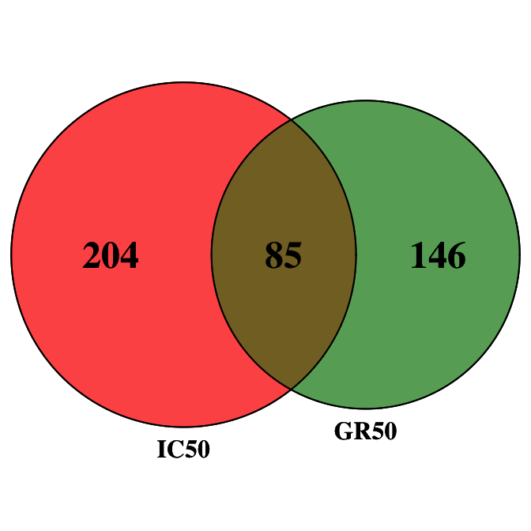

```r
Associations_overlap(results_RecomputedLNIC50_GRset,results_LNGR50_GRset,c("IC50","GR50"),"IC50_GR50.jpeg",c("red","forest green"))
```

Find the associations that overlap between Emax and GRmax (Figure 4a)

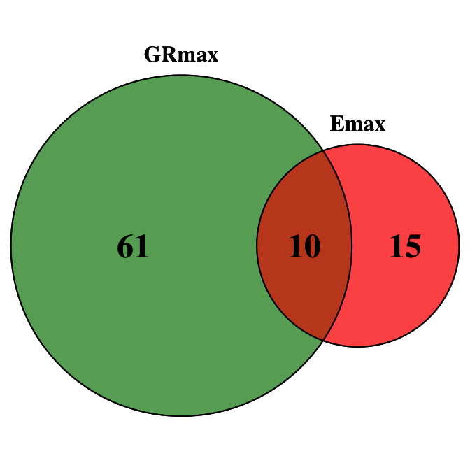

```r
Associations_overlap(results_Emax_GRset,results_GRmax_GRset,c("Emax","GRmax"),"Emax_GRmax.jpeg",c("red","forest green"))
```

Data that shows the overlaps at different association thresholds (Figure 4b)

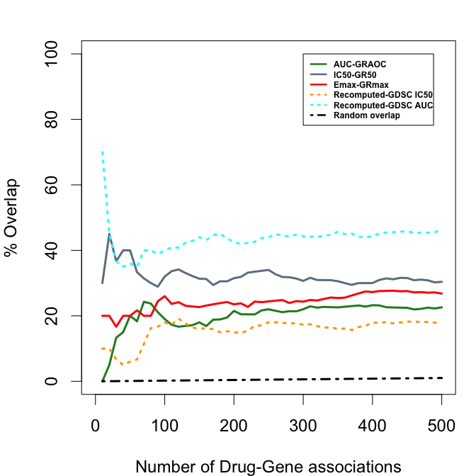

```r
AUC_AOC_overlap<-Associations_overlap_percentages(results_RecomputedAUC_GRset,results_GRAOC_GRset,"AUC","GRAOC")
IC50_GR50_overlap<-Associations_overlap_percentages(results_RecomputedLNIC50_GRset,results_LNGR50_GRset,"IC50","GR50")
Emax_GRmax_overlap<-Associations_overlap_percentages(results_Emax_GRset,results_GRmax_GRset,"Emax","GRmax")
Recomputed_GDSC_IC50_overlap<-Associations_overlap_percentages(results_RecomputedLNIC50_GRset,results_GDSC_LNIC50_GRset,"RecomputedIC50","GDSCIC50")
Recomputed_GDSC_AUC_overlap<-Associations_overlap_percentages(results_RecomputedAUC_GRset,results_GDSC_AUC_GRset,"RecomputedAUC","GDSC_AUC")
Random_overlap<-Random_coincidence(results_RecomputedAUC_GRset)

#jpeg("Conventional_GR_Associations_Overlap.jpeg")
par(cex=1,mar=c(4,4,2,1),cex.lab=1,cex=1.5,font=2)

#Plot the number of drug-gene associations against the percentage overlap
plot(AUC_AOC_overlap$Assoc_Threshold,AUC_AOC_overlap$overlap,xlab="Number of Drug-Gene associations",ylab="% Overlap",col="forestgreen",pch=16,type="l",lty=1,lwd=3,cex.axis=1,xlim=c(0,500),ylim=c(0,100))
points(IC50_GR50_overlap$Assoc_Threshold,IC50_GR50_overlap$overlap,col="slategrey",pch=16,type='l',lty=1,lwd=3,xlim=c(0,500),ylim=c(0,100))
points(Emax_GRmax_overlap$Assoc_Threshold,Emax_GRmax_overlap$overlap,col="red",pch=16,type='l',lty=1,lwd=3,xlim=c(0,500),ylim=c(0,100))
points(Recomputed_GDSC_IC50_overlap$Assoc_Threshold,Recomputed_GDSC_IC50_overlap$overlap,col="orange",pch=16,type='l',lty=3,lwd=3,xlim=c(0,500),ylim=c(0,100))
points(Recomputed_GDSC_AUC_overlap$Assoc_Threshold,Recomputed_GDSC_AUC_overlap$overlap,col="cyan",pch=16,type='l',lty=3,lwd=3,xlim=c(0,500),ylim=c(0,100))
points(Random_overlap$Assoc_Threshold,Random_overlap$overlap,col="black",pch=16,type='l',lty=4,lwd=3,xlim=c(0,500),ylim=c(0,100))

legend(300,100,c("AUC-GRAOC","IC50-GR50","Emax-GRmax","Recomputed-GDSC IC50","Recomputed-GDSC AUC","Random overlap"),lty=c(1,1,1,3,3,4),lwd=c(2.5,2.5,2.5,2.5,2.5,2.5),cex=0.5,col=c("forestgreen","slategrey","red","orange","cyan","black"))
```

```r
#dev.off()
```

Histogram showing the distribution of random overlaps based on different association thresholds (Figure 4b)

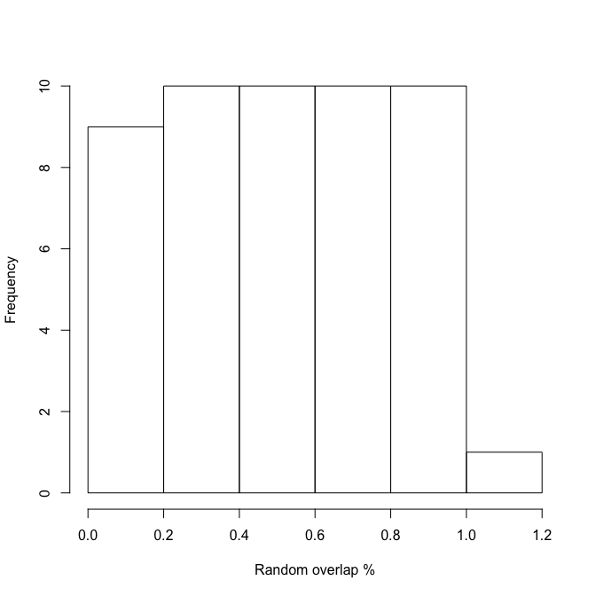

```r
#jpeg("RandomOverlap_Dist.jpeg")
hist(Random_overlap$overlap,xlab="Random overlap %",main="")
```

```r
#dev.off()
```

Find the associations that overlap between GDSC IC50 and Recomputed IC50 (Figure 16)

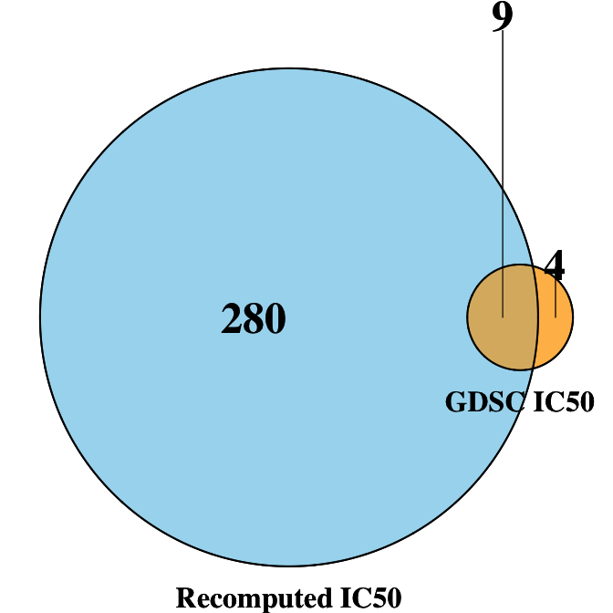

```r
Associations_overlap(results_RecomputedLNIC50_GRset,results_GDSC_LNIC50_GRset,c("Recomputed IC50","GDSC IC50"),"GDSC_RecomputedIC50.jpeg",c("skyblue","orange"))
```

Find the associations that overlap between GDSC AUC and Recomputed AUC (Figure 16)

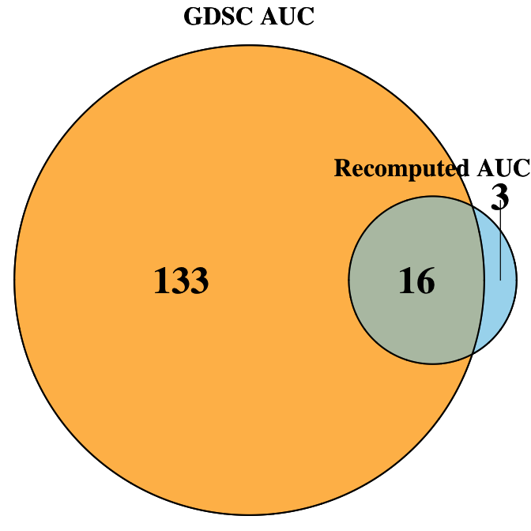

```r
Associations_overlap(results_RecomputedAUC_GRset,results_GDSC_AUC_GRset,c("Recomputed AUC","GDSC AUC"),"GDSC_RecomputedAUC.jpeg",c("skyblue","orange"))
```

Compare the FDRs of 2 different metrics to find out the associations that found in one but not the other; Only those associations with FDR < 10% are highlighted here (Figure 5, Top panel)

Function to plot the FDRs

```r
FDR_comp<-function(metric1,metric2,Fig_FileName,label1,label2,main_heading,legend_labels,pos1,pos2)
{
  #Merge the 2 metrics
  Diff_metrics_mergeFDRs<-merge(metric1, metric2, by=c("FEATURE","DRUG_NAME"))
  Metric1_Metric2_FDR_assoc<-cbind.data.frame(Assoc=paste(Diff_metrics_mergeFDRs$DRUG_NAME,Diff_metrics_mergeFDRs$FEATURE,sep="-"),Metric1_FDR=as.vector(-log10(Diff_metrics_mergeFDRs$ANOVA_FEATURE_FDR.x/100)),Metric2_FDR=as.vector(-log10(Diff_metrics_mergeFDRs$ANOVA_FEATURE_FDR.y/100)))

  #Pick only those associations with FDR < 10%
  Metric1_FDR_extract<- Metric1_Metric2_FDR_assoc[which(Metric1_Metric2_FDR_assoc$Metric1_FDR>1),]
  Metric2_FDR_extract<- Metric1_Metric2_FDR_assoc[which(Metric1_Metric2_FDR_assoc$Metric2_FDR>1),]

  #jpeg(filename=Fig_FileName,quality=100)
  par(cex=1,mar=c(4,4,2,1),cex.lab=0.75,cex=1.5,font=2)
  plot(Metric1_Metric2_FDR_assoc$Metric1_FDR,Metric1_Metric2_FDR_assoc$Metric2_FDR,xlab=label1,ylab=label2,main=main_heading,col="slate gray",pch=16,cex.axis=1)

  #Highlight those associations that are significant and found in one metric, but not the other
  points(Metric1_FDR_extract$Metric1_FDR,Metric1_FDR_extract$Metric2_FDR,col="red",pch=16)
  points(Metric2_FDR_extract$Metric1_FDR,Metric2_FDR_extract$Metric2_FDR,col="green",pch=16)
  legend(pos1,pos2,legend_labels,pch=16,cex=0.5,col=c("green","red"))
  #dev.off()
}
```

Plot the FDRs of IC50s and GR50s

```r
IC50_GR50_FDR <- FDR_comp(results_RecomputedLNIC50_GRset,results_LNGR50_GRset,"IC50_GR50_FDRcomp.jpeg","-log10(Adjusted p values:IC50)","-log10(Adjusted p values:GR50)","IC50 vs GR50",c("IC50_FDR < 10","GR50_FDR < 10"),13,20)
```

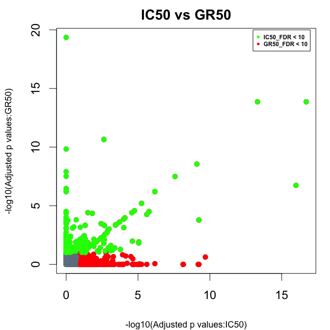

Plot the FDRs of AUCs and GRAOCs

```r
AUC_GRAOC_FDR <- FDR_comp(results_RecomputedAUC_GRset,results_GRAOC_GRset,"AUC_GRAOC_FDRcomp.jpeg","-log10(Adjusted p values:AUC)","-log10(Adjusted p values:GRAOC)","AUC vs GRAOC",c("AUC_FDR < 10","GRAOC_FDR < 10"),4,5)
```

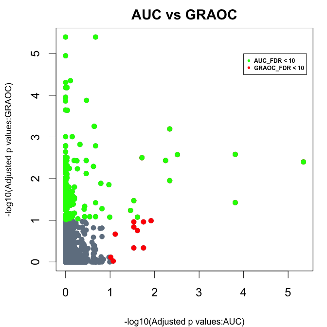

Compare the FDRs of 2 different metrics to find out the distribution of known associations (highlighted in orange); Figure 5, Bottom panel

Function to plot the FDRs and highlight known associations

```r
data("GDSC_KnownAssociations",package = "AlternativeDrugResponseMetrics")
FDR_KnownAssoc<-function(metric1,metric2,Fig_FileName,label1,label2,main_heading,legend_labels,pos1,pos2)
{
  Metric1_Metric2_FDR_merged<-merge(metric1, metric2, by=c("DRUG_NAME","FEATURE"))
  Metric1_Metric2_FDR_merged_DrugFeature<-cbind.data.frame(Metric1_Metric2_FDR_merged,Ident_Drug_Feature=paste(as.vector(Metric1_Metric2_FDR_merged$DRUG_NAME),as.vector(Metric1_Metric2_FDR_merged$FEATURE),sep="-"))
 Metric1_Metric2_FDR_merged_assoc_extract<-Metric1_Metric2_FDR_merged_DrugFeature[grepl(paste(as.vector(GDSC_KnownAssociations$Ident_Drug_Feature),collapse="|"),as.vector(Metric1_Metric2_FDR_merged_DrugFeature$Ident_Drug_Feature)),]

  Metric1_Metric2_FDR_assoc<-cbind.data.frame(Assoc=paste(Metric1_Metric2_FDR_merged$DRUG_NAME,Metric1_Metric2_FDR_merged$FEATURE,sep="-"),Metric1_FDR=as.vector(-log10(Metric1_Metric2_FDR_merged$ANOVA_FEATURE_FDR.x/100)),Metric2_FDR=as.vector(-log10(Metric1_Metric2_FDR_merged$ANOVA_FEATURE_FDR.y/100)))
Metric1_FDR_extract<-Metric1_Metric2_FDR_assoc[which(Metric1_Metric2_FDR_assoc$Metric1_FDR>1),]
Metric2_FDR_extract<-Metric1_Metric2_FDR_assoc[which(Metric1_Metric2_FDR_assoc$Metric2_FDR>1),]

#jpeg(filename=Fig_FileName,quality=100)
par(cex=1,mar=c(4,4,2,1),cex.lab=0.75,cex=1.5,font=2)
plot(Metric1_Metric2_FDR_assoc$Metric1_FDR,Metric1_Metric2_FDR_assoc$Metric2_FDR,xlab=label1,ylab=label2, main= main_heading,col="light gray",pch=16,cex.axis=1)
points(as.vector(-log10(Metric1_Metric2_FDR_merged_assoc_extract$ANOVA_FEATURE_FDR.x/100)),as.vector(-log10(Metric1_Metric2_FDR_merged_assoc_extract$ANOVA_FEATURE_FDR.y/100)),col="orange",pch=16)
legend(pos1,pos2,legend_labels,pch=16,cex=0.5,col=c("light gray","orange"))
#dev.off()
}
```

Plot the FDRs of IC50s and GR50s with known associations

```r
IC50_GR50_FDR_KnownAssoc <- FDR_KnownAssoc(results_RecomputedLNIC50_GRset,results_LNGR50_GRset,"IC50_GR50_FDRcomp_KnownAssoc.jpeg","-log10(Adjusted p values:IC50)","-log10(Adjusted p values:GR50)","IC50 vs GR50",c("AllAssoc","KnownAssoc"),13,19)
```

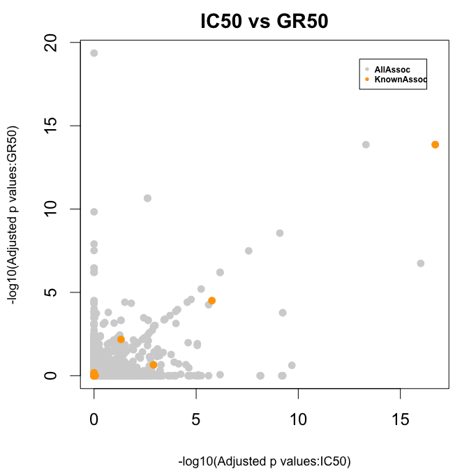

Plot the FDRs of AUCs and GRAOCs with known associations

```r
AUC_GRAOC_FDR_KnownAssoc <- FDR_KnownAssoc(results_RecomputedAUC_GRset,results_GRAOC_GRset,"AUC_GRAOC_FDRcomp_KnownAssoc.jpeg","-log10(Adjusted p values:AUC)","-log10(Adjusted p values:GRAOC)","AUC vs GRAOC",c("AllAssoc","KnownAssoc"),4.3,4.8)
```

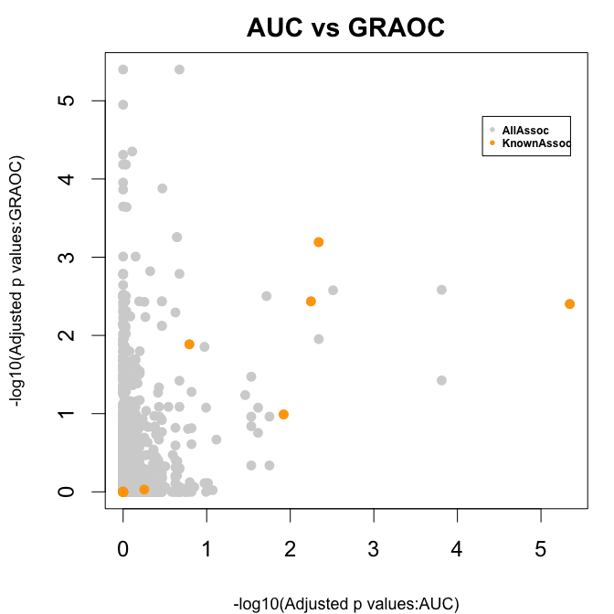

Compute distance to drug targets to find out how relevant are the drug gene interactions identified through ANOVA analysis of different drug response metrics

```r
library("igraph")
data("OmniPathNW",package = "AlternativeDrugResponseMetrics")
data("Orig_Target",package = "AlternativeDrugResponseMetrics")
system("mkdir Calculated_Values")

RecomputedIC50_Dist<-Distances_DrugTargets(results_RecomputedLNIC50_GRset,write.File=F,"Recomputed_IC50_DistanceToTargets_FDR10")
GDSC_IC50_Dist<-Distances_DrugTargets(results_GDSC_LNIC50_GRset,write.File=F,"GDSC_IC50_DistanceToTargets_FDR10")
GR50_Dist<-Distances_DrugTargets(results_LNGR50_GRset,write.File=F,"GR50_DistanceToTargets_FDR10")
RecomputedAUC_Dist<-Distances_DrugTargets(results_RecomputedAUC_GRset,write.File=F,"Recomputed_AUC_DistanceToTargets_FDR10")
GDSC_AUC_Dist<-Distances_DrugTargets(results_GDSC_AUC_GRset,write.File=F,"GDSC_AUC_DistanceToTargets_FDR10")
GRAOC_Dist<-Distances_DrugTargets(results_GRAOC_GRset,write.File=F,"GRAOC_DistanceToTargets_FDR10")
```

Generate histograms to show the distribution of distances to drug targets (Figure 7, Top panel)

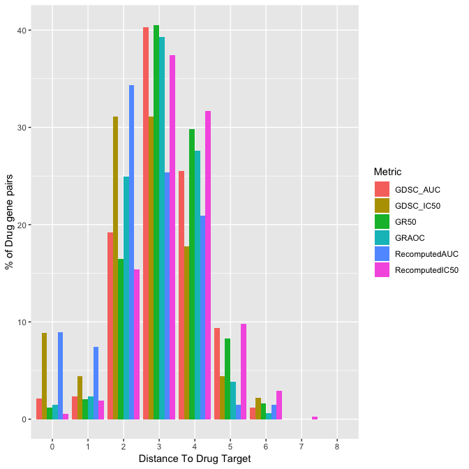

```r
library("ggplot2")
Dist_Data<- lapply(ls(pattern="_Dist"), get)

Metric_type<-c("GDSC_AUC","GDSC_IC50","GR50","GRAOC","RecomputedAUC","RecomputedIC50")
AllMetrics<-c()
for(i in 1:length(Dist_Data))
{
  Metric_dist_all<-Dist_Data[[i]]

  #Remove those entries for which the distances between FDR and Original targets is infinite;Only definite distances considered
  Metric_dist<- Metric_dist_all[-(which(Metric_dist_all$Path_length == "Inf")),]

    #Group the distances
  Paths_ranges<-split(Metric_dist, cut(Metric_dist$Path_length, c(-1,0,1,2,3,4,5,6,7,8), include.lowest=TRUE))
  Paths_ranges_no<-sapply(Paths_ranges,function(x) nrow(x[1:length(x)]))
  Percentage_Paths_ranges_no<-sapply(Paths_ranges_no,function(x) (x/nrow(Metric_dist))*100)
  Paths_lengths<-c("0","1","2","3","4","5","6","7","8")
  Metric_paths<-cbind.data.frame(Metric=Metric_type[i],Paths_lengths,Paths_ranges_no, Percentage_Paths_ranges_no)
  AllMetrics<-rbind(AllMetrics,Metric_paths)
}

#jpeg(filename="DistanceToDrugTargets_AllMetrics_IC_GR_PercentageDistPlots_allTargets_FDR10.jpeg")
par(cex=1,mar=c(4,4,2,1),cex.lab=1,cex=1.5,font=2)
ggplot( AllMetrics, aes(fill=Metric, y=Percentage_Paths_ranges_no, x=Paths_lengths)) +
  geom_bar(position="dodge", stat="identity")+xlab("Distance To Drug Target")+ylab("% of Drug gene pairs")
```

```r
#dev.off()
```

Generate histograms to compare how good are the different metrics in identifying the actual drug targets (Figure 7, Bottom panel)

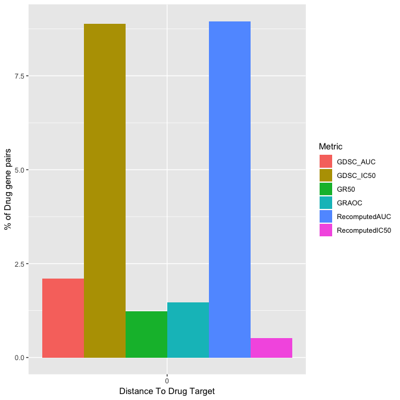

```r
library("ggplot2")
Dist_Data<- lapply(ls(pattern="_Dist"), get)

Metric_type<-c("GDSC_AUC","GDSC_IC50","GR50","GRAOC","RecomputedAUC","RecomputedIC50")
AllMetrics<-c()
for(i in 1:length(Dist_Data))
{
  Metric_dist_all<-Dist_Data[[i]]

  #Remove those entries for which the distances between FDR and Original targets is infinite;      Only definite distances considered
  Metric_dist<- Metric_dist_all[-(which(Metric_dist_all$Path_length == "Inf")),]

    #Group the distances
  Paths_ranges<-split(Metric_dist, cut(Metric_dist$Path_length, c(-1,0), include.lowest=TRUE))
  Paths_ranges_no<-sapply(Paths_ranges,function(x) nrow(x[1:length(x)]))
  Percentage_Paths_ranges_no<-sapply(Paths_ranges_no,function(x) (x/nrow(Metric_dist))*100)
  Paths_lengths<-c("0")
  Metric_paths<-cbind.data.frame(Metric=Metric_type[i],Paths_lengths,Paths_ranges_no, Percentage_Paths_ranges_no)
  AllMetrics<-rbind(AllMetrics,Metric_paths)
}

#jpeg(filename="DistanceToDrugTargets_AllMetrics_IC_GR_PercentageDistPlots_actualTargets_FDR10.jpeg")
par(cex=1,mar=c(4,4,2,1),cex.lab=1,cex=1.5,font=2)
ggplot( AllMetrics, aes(fill=Metric, y=Percentage_Paths_ranges_no, x=Paths_lengths)) +
  geom_bar(position="dodge", stat="identity")+xlab("Distance To Drug Target")+ylab("% of Drug gene pairs")
```

```r
#dev.off()
```

For some drugs, we have multiple measurements distinguished by their IDs. It’s not advisable to use the same chemical descriptors and have different actvities in a machine learning models. So, average values of the activities are used for those drugs in Machine learning models. For details, see the code below.

```r
data("Conventional_GR_allCalculatedMetrics_merged",package = "AlternativeDrugResponseMetrics")
data("GDSC_DrugIDs_Names_mapped",package = "AlternativeDrugResponseMetrics")

#Map the drug ids to drug names
GDSC_DrugNames_IDs_merged<-merge(Conventional_GR_allCalculatedMetrics_merged,GDSC_DrugIDs_Names_mapped,by.x="Drug",by.y="DRUG_ID")
colnames(GDSC_DrugNames_IDs_merged)[1]="ID"
colnames(GDSC_DrugNames_IDs_merged)[19]="Drug"
Unique_GCSI_drugs_list<-unique(GDSC_DrugNames_IDs_merged$Drug)
AllDrugs_IC50s_GR50<-c()
for(i in 1:length(Unique_GCSI_drugs_list))
{
GCSI_drug_extract<-GDSC_DrugNames_IDs_merged[GDSC_DrugNames_IDs_merged$Drug==Unique_GCSI_drugs_list[i],c("CellLine","LN_GR50","LN_IC50","AUC","GRAOC")]

#Compute the averages of those drug-cell line pairs present multiple times
GCSI_drug_extract_averaged<-with(GCSI_drug_extract,aggregate(GCSI_drug_extract,by=list(CellLine=CellLine),mean))
Drugs_Activities_combined<-cbind.data.frame(Drug=Unique_GCSI_drugs_list[i],GCSI_drug_extract_averaged)
write.table(Drugs_Activities_combined,file="Calculated_Values/GDSC_240Drugs_AveragedResponses_Duplicates_June2018.txt",sep="\t",quote=FALSE,row.names=FALSE,col.names=FALSE,append=TRUE)
}
```

Generate boxplots to show the performances of the models (Figure 9)

All model performances from different splits and different metrics are used for generating box plots

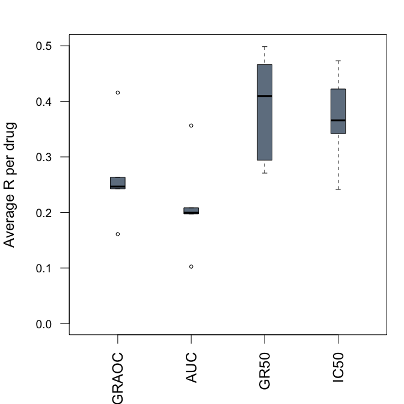

```r
data("Test_R_Drug_AllMetrics",package = "AlternativeDrugResponseMetrics")
#jpeg(filename="DrugResponse_Predictions_boxplots.jpeg")
par(cex=1,mar=c(4,4,2,1),cex.lab=1,cex=1.5,font=2)
boxplot(Test_R_Drug_AllMetrics,boxwex=0.2,staplewex=0.3,outwex=0.3,at=1:4,names=c("GRAOC","AUC","GR50","IC50"),las=2,cex=0.5,cex.axis=0.8,xaxt="n",ylim=c(0,0.5),ylab="Average R per drug",col="slategrey",outpch=1,font.axis=2)
axis(1,labels=c("GRAOC","AUC","GR50","IC50"),at=1:4,las=2,font.axis=1,cex=0.8)
```

```r
#dev.off()
```

Generate scatter plots to check the influence of division times on IC50 and GR50 (Figure 10 in the report)

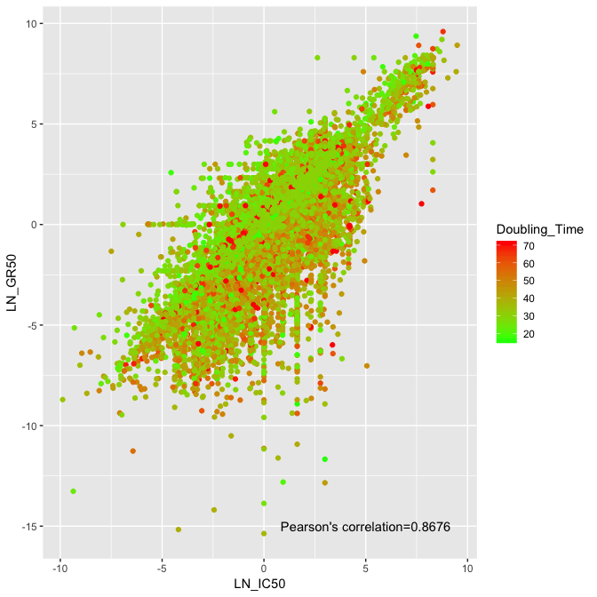

```r
data("Conventional_GR_allCalculatedMetrics_merged",package = "AlternativeDrugResponseMetrics")
data("Genentech_GCSI_DivisionTimes_CellLines",package = "AlternativeDrugResponseMetrics")
Response_DivisionTimes_merged<-merge(Conventional_GR_allCalculatedMetrics_merged,Genentech_GCSI_DivisionTimes_CellLines,by="CellLine")
correlation_DivTimes=cor(Response_DivisionTimes_merged$LN_IC50,Response_DivisionTimes_merged$LN_GR50)
#jpeg(filename="DoublingTime_IC50_GR50_ggplots_colored.jpeg")
par(cex=1,mar=c(4,4,2,1),cex.lab=1,cex=1.5,font=2)
ggplot(Response_DivisionTimes_merged,aes(x=LN_IC50,y=LN_GR50,color=Doubling_Time))+geom_point()+scale_color_gradient(low="green",high="red")+annotate(geom="text",label=paste("Pearson's correlation=",round(correlation_DivTimes,digits=4),sep=""),x=5,y=-15,color="black")
```

```r
#dev.off()
```

Load data corresponding to different metrics (IC, GR, NDR and PI) and obtain the p-values.

```r
library(AlternativeDrugResponseMetrics)
l_NDRset <- grep("_NDRset",data(package="AlternativeDrugResponseMetrics")$results[,"Item"],value = T)
NDRset_Data = new.env()
data(list=l_NDRset,envir = NDRset_Data)
pvalue_ranges<-seq(0,10,by=0.2)
Pvalues_allMetrics<-data.frame(pvalue_ranges)

for(iMetric in ls(NDRset_Data))
{
    #Extract the FDR from each of the ANOVA results file
    Allgenes_pvalues <- NDRset_Data[[iMetric]]
    Allgenes_pvalues_corrected<-as.data.frame(sapply(Allgenes_pvalues$ANOVA_FEATURE_FDR, function(x) -log10(x/100)))
    p_adjusted_values_allgenes<-Allgenes_pvalues_corrected[,1]
    Allpvalues_allGenes<-c()

    for(j in 1:length(pvalue_ranges))
    {
        #Extract the number of drug gene associations for the different p value ranges
        Adjustedvalues_WithinRange_allGenes <- length( subset( p_adjusted_values_allgenes, p_adjusted_values_allgenes > pvalue_ranges[j] ))
        Allpvalues_allGenes <- c(Allpvalues_allGenes, log10(Adjustedvalues_WithinRange_allGenes))
    }
    Pvalues_allMetrics <- cbind.data.frame(Pvalues_allMetrics,as.data.frame(Allpvalues_allGenes))
}

headers_Pvalues_allMetrics<-gsub("results_","",ls(NDRset_Data))
colnames(Pvalues_allMetrics)<-c("pvalue_ranges",headers_Pvalues_allMetrics)

head(Pvalues_allMetrics)
```

```
#>   pvalue_ranges AUC_NDRset GR50_NDRset GRAOC_NDRset IC50_NDRset
#> 1           0.0   4.850652    3.659631     4.850652    3.782258
#> 2           0.2   2.721811    3.139564     2.706718    3.265996
#> 3           0.4   2.307496    2.857935     2.387390    2.979548
#> 4           0.6   2.096910    2.655138     2.152288    2.820201
#> 5           0.8   1.929419    2.525045     2.049218    2.669317
#> 6           1.0   1.806180    2.409933     1.913814    2.553883
#>   NDR50_NDRset NDRAOC_NDRset PI50_NDRset PIAOC_NDRset
#> 1     3.713826      3.357363    3.563362     4.850652
#> 2     3.147367      3.053078    3.447778     2.721811
#> 3     2.869818      2.876795    3.353147     2.307496
#> 4     2.673942      2.765669    3.280578     2.096910
#> 5     2.536558      2.696356    3.209247     1.929419
#> 6     2.414973      2.641474    3.135769     1.806180
```

Generate ANOVA plots (Figure 11)

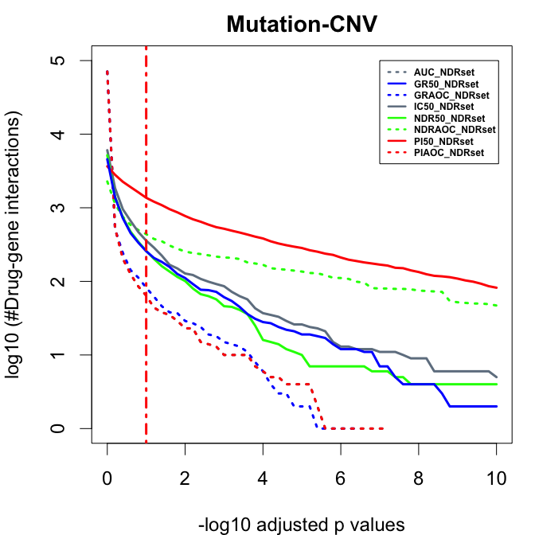

```r
#jpeg("AllANOVA_IC_NDR_PI_GR_50Metrics_plots.jpeg")
par(cex=1,mar=c(4,4,2,1),cex.lab=1,cex=1.5,font=2)

#Plot the p values against the number of drug-gene associations
plot(Pvalues_allMetrics$pvalue_ranges,Pvalues_allMetrics$AUC_NDRset,xlab="-log10 adjusted p values",ylab="log10 (#Drug-gene interactions)",main="Mutation-CNV",col="slategrey",pch=16,type="l",lty=3,lwd=3,cex.axis=1,xlim=c(0,10),ylim=c(0,5))
points(Pvalues_allMetrics$pvalue_ranges,Pvalues_allMetrics$GRAOC_NDRset,col="blue",pch=16,type='l',lty=3,lwd=3,xlim=c(0,10),ylim=c(0,5))
points(Pvalues_allMetrics$pvalue_ranges,Pvalues_allMetrics$NDRAOC_NDRset,col="green",pch=16,type='l',lty=3,lwd=3,xlim=c(0,10),ylim=c(0,5))
points(Pvalues_allMetrics$pvalue_ranges,Pvalues_allMetrics$PIAOC_NDRset,col="red",pch=16,type='l',lty=3,lwd=3,xlim=c(0,10),ylim=c(0,5))
points(Pvalues_allMetrics$pvalue_ranges,Pvalues_allMetrics$IC50_NDRset,col="slategrey",pch=16,type='l',lty=1,lwd=3,xlim=c(0,10),ylim=c(0,5))
points(Pvalues_allMetrics$pvalue_ranges,Pvalues_allMetrics$NDR50_NDRset,col="green",pch=16,type='l',lty=1,lwd=3,xlim=c(0,10),ylim=c(0,5))
points(Pvalues_allMetrics$pvalue_ranges,Pvalues_allMetrics$PI50_NDRset,col="red",pch=16,type='l',lty=1,lwd=3,xlim=c(0,10),ylim=c(0,5))
points(Pvalues_allMetrics$pvalue_ranges,Pvalues_allMetrics$GR50_NDRset,col="blue",pch=16,type='l',lty=1,lwd=3,xlim=c(0,10),ylim=c(0,5))
abline (v=1,col="red",lty=4,lwd=3)
legend(7,5,c(headers_Pvalues_allMetrics[1],headers_Pvalues_allMetrics[2],headers_Pvalues_allMetrics[3],headers_Pvalues_allMetrics[4],headers_Pvalues_allMetrics[5],headers_Pvalues_allMetrics[6],headers_Pvalues_allMetrics[7],headers_Pvalues_allMetrics[8]),lty=c(3,1,3,1,1,3,1,3),lwd=c(2.5,2.5,2.5,2.5,2.5,2.5,2.5,2.5),cex=0.5,col=c("slategrey","blue","blue","slategrey","green","green","red","red"))
```

```r
#dev.off()
```

Compute distance to drug targets to find out how relevant are the drug gene interactions identified through ANOVA analysis of different drug response metrics (NDR dataset and all metrics)

```r
library("igraph")
data("OmniPathNW",package = "AlternativeDrugResponseMetrics")
data("Orig_Target",package = "AlternativeDrugResponseMetrics")

IC50_NDRset_Dist<-Distances_DrugTargets(results_IC50_NDRset,write.File=F,"IC50_NDRset_DistanceToTargets_FDR10")
GR50_NDRset_Dist<-Distances_DrugTargets(results_GR50_NDRset,write.File=F,"GR50_NDRset_DistanceToTargets_FDR10")
NDR50_NDRset_Dist<-Distances_DrugTargets(results_NDR50_NDRset,write.File=F,"NDR50_NDRset_DistanceToTargets_FDR10")
PI50_NDRset_Dist<-Distances_DrugTargets(results_PI50_NDRset,write.File=F,"PI50_NDRset_DistanceToTargets_FDR10")


AUC_NDRset_Dist<-Distances_DrugTargets(results_AUC_NDRset,write.File=F,"AUC_NDRset_DistanceToTargets_FDR10")
GRAOC_NDRset_Dist<-Distances_DrugTargets(results_GRAOC_NDRset,write.File=F,"GRAOC_NDRset_DistanceToTargets_FDR10")
NDRAOC_NDRset_Dist<-Distances_DrugTargets(results_NDRAOC_NDRset,write.File=F,"NDRAOC_NDRset_DistanceToTargets_FDR10")
PIAOC_NDRset_Dist<-Distances_DrugTargets(results_PIAOC_NDRset,write.File=F,"PIAOC_NDRset_DistanceToTargets_FDR10")
```

Generate histograms to show the distribution of distances to drug targets (Figure 12, Top panel)

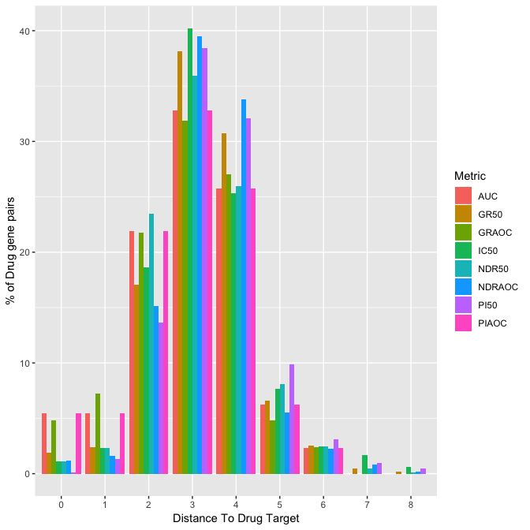

```r
library("ggplot2")
Dist_NDRset_Data<- lapply(ls(pattern="_NDRset_Dist"), get)

Metric_type<-c("AUC","GR50","GRAOC","IC50","NDR50","NDRAOC","PI50","PIAOC")
AllMetrics<-c()
for(i in 1:length(Dist_NDRset_Data))
{
  Metric_dist_all<-Dist_NDRset_Data[[i]]

  #Remove those entries for which the distances between FDR and Original targets is infinite;      Only definite distances considered
  Metric_dist<- Metric_dist_all[-(which(Metric_dist_all$Path_length == "Inf")),]

    #Group the distances
  Paths_ranges<-split(Metric_dist, cut(Metric_dist$Path_length, c(-1,0,1,2,3,4,5,6,7,8), include.lowest=TRUE))
  Paths_ranges_no<-sapply(Paths_ranges,function(x) nrow(x[1:length(x)]))
  Percentage_Paths_ranges_no<-sapply(Paths_ranges_no,function(x) (x/nrow(Metric_dist))*100)
  Paths_lengths<-c("0","1","2","3","4","5","6","7","8")
  Metric_paths<-cbind.data.frame(Metric=Metric_type[i],Paths_lengths,Paths_ranges_no, Percentage_Paths_ranges_no)
  AllMetrics<-rbind(AllMetrics,Metric_paths)
}

#jpeg(filename="DistanceToDrugTargets_AllMetrics_IC_NDR_GR_PI_PercentageDistPlots_allTargets_FDR10.jpeg")
par(cex=1,mar=c(4,4,2,1),cex.lab=1,cex=1.5,font=2)
ggplot( AllMetrics, aes(fill=Metric, y=Percentage_Paths_ranges_no, x=Paths_lengths)) +
  geom_bar(position="dodge", stat="identity")+xlab("Distance To Drug Target")+ylab("% of Drug gene pairs")
```

```r
#dev.off()
```

Generate histograms to compare how good are the different metrics in identifying the actual drug targets (Figure 12, Bottom panel)

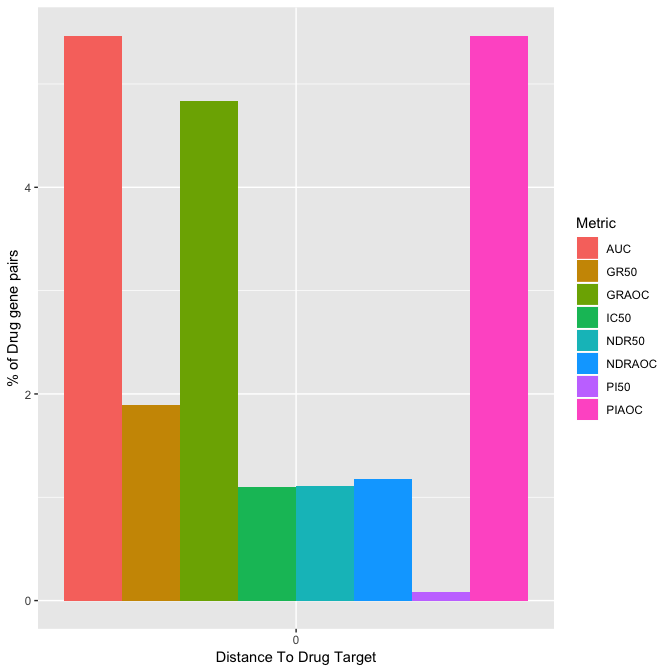

```r
library("ggplot2")
Dist_NDRset_Data<- lapply(ls(pattern="_NDRset_Dist"), get)

Metric_type<-c("AUC","GR50","GRAOC","IC50","NDR50","NDRAOC","PI50","PIAOC")
AllMetrics<-c()
for(i in 1:length(Dist_NDRset_Data))
{
  Metric_dist_all<-Dist_NDRset_Data[[i]]

  #Remove those entries for which the distances between FDR and Original targets is infinite;      Only definite distances considered
  Metric_dist<- Metric_dist_all[-(which(Metric_dist_all$Path_length == "Inf")),]

    #Group the distances
  Paths_ranges<-split(Metric_dist, cut(Metric_dist$Path_length, c(-1,0), include.lowest=TRUE))
  Paths_ranges_no<-sapply(Paths_ranges,function(x) nrow(x[1:length(x)]))
  Percentage_Paths_ranges_no<-sapply(Paths_ranges_no,function(x) (x/nrow(Metric_dist))*100)
  Paths_lengths<-c("0")
  Metric_paths<-cbind.data.frame(Metric=Metric_type[i],Paths_lengths,Paths_ranges_no, Percentage_Paths_ranges_no)
  AllMetrics<-rbind(AllMetrics,Metric_paths)
}

#jpeg(filename="DistanceToDrugTargets_AllMetrics_IC_NDR_PI_GR_PercentageDistPlots_actualTargets_FDR10.jpeg")
par(cex=1,mar=c(4,4,2,1),cex.lab=1,cex=1.5,font=2)
ggplot( AllMetrics, aes(fill=Metric, y=Percentage_Paths_ranges_no, x=Paths_lengths)) +
  geom_bar(position="dodge", stat="identity")+xlab("Distance To Drug Target")+ylab("% of Drug gene pairs")
```

```r
#dev.off()
```

Find the associations that overlap between IC50 and NDR50 (Figure 14)

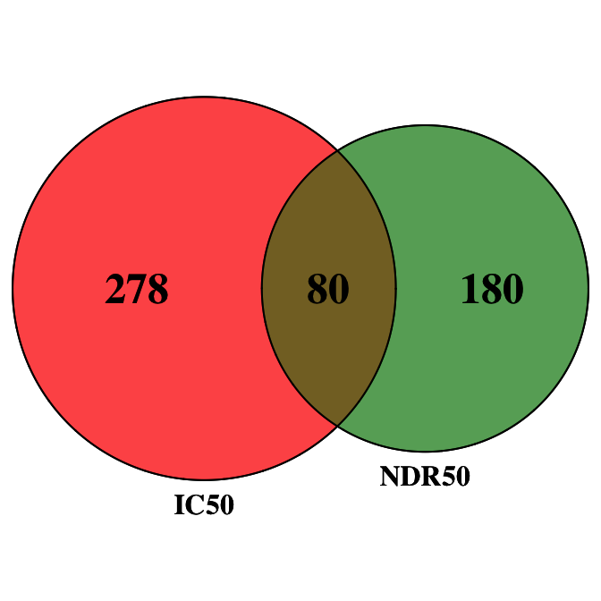

```r
l_NDRset <- grep("_NDRset",data(package="AlternativeDrugResponseMetrics")$results[,"Item"],value = T)
NDRset_Data = new.env()
data(list=l_NDRset,envir = NDRset_Data)
Associations_overlap(results_IC50_NDRset,results_NDR50_NDRset,c("IC50","NDR50"),"IC50_NDR50.jpeg",c("red","forest green"))
```

Find the associations that overlap between AUC and NDRAOC (Figure 14)

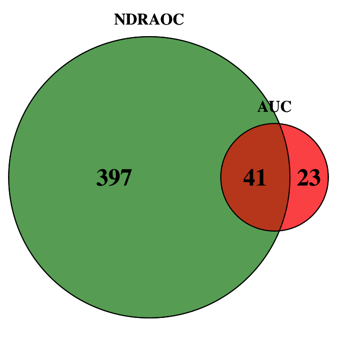

```r
Associations_overlap(results_AUC_NDRset,results_NDRAOC_NDRset,c("AUC","NDRAOC"),"AUC_NDRAOC.jpeg",c("red","forest green"))
```

Find the associations that overlap between GR50 and NDR50 (Figure 15)

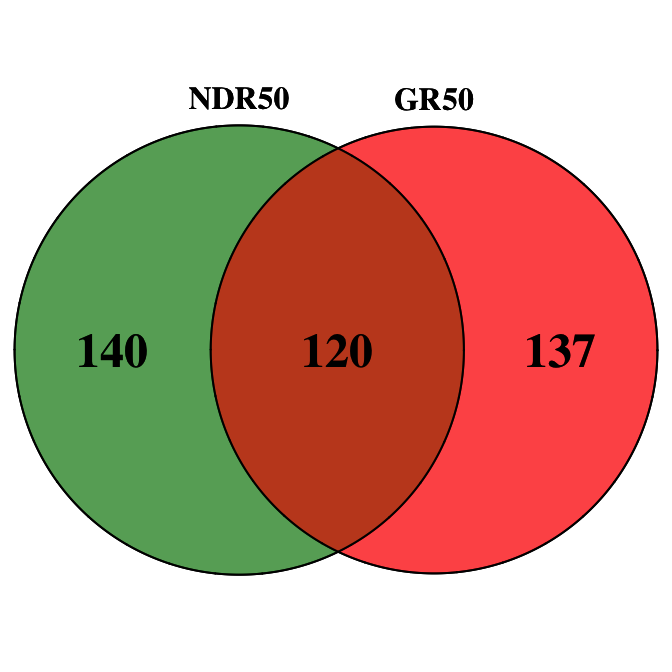

```r
Associations_overlap(results_GR50_NDRset,results_NDR50_NDRset,c("GR50","NDR50"),"GR50_NDR50.jpeg",c("red","forest green"))
```

Find the associations that overlap between GRAOC and NDRAOC (Figure 15)

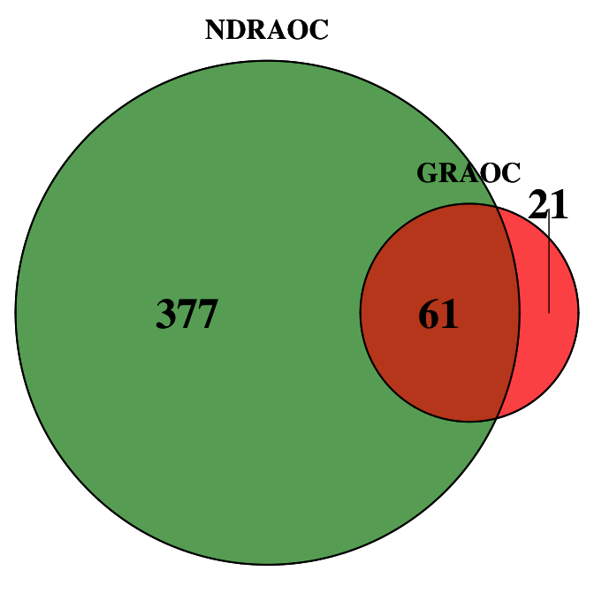

```r
Associations_overlap(results_GRAOC_NDRset,results_NDRAOC_NDRset,c("GRAOC","NDRAOC"),"GRAOC_NDRAOC.jpeg",c("red","forest green"))
```

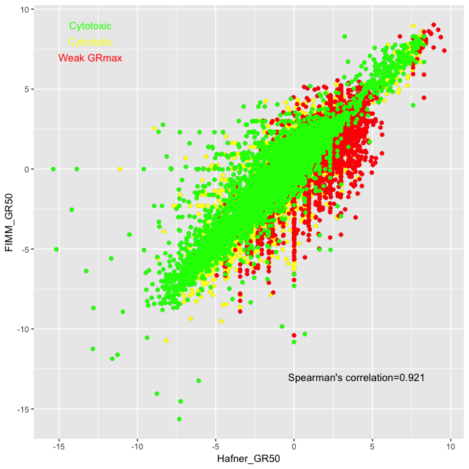

```r
data("Conventional_GR_allCalculatedMetrics_merged",package = "AlternativeDrugResponseMetrics")
data("AllMetrics_merged_NDRdata",package = "AlternativeDrugResponseMetrics")
Hafner_FIMM_GR_merged<-merge(Conventional_GR_allCalculatedMetrics_merged,AllMetrics_merged_NDRset,by=c("CellLine","Drug"))

#Extract the GRmax values and group the GR50s based on strong (GRmax>1), moderate (0 > GRmax < 1) or weak responses (GRmax>1)
Cytotoxic<-Hafner_FIMM_GR_merged[which(Hafner_FIMM_GR_merged$GRmax.x<0),]
Cytostatic<-Hafner_FIMM_GR_merged[which(Hafner_FIMM_GR_merged$GRmax.x>=0 & Hafner_FIMM_GR_merged$GRmax.x<0.5),]
GRmax_weak<-Hafner_FIMM_GR_merged[which(Hafner_FIMM_GR_merged$GRmax.x>=0.5),]

#jpeg(filename="Hafner_FIMM_GR50_correlation_plots_ColoredByGRmax.jpeg")
par(cex=1,mar=c(4,4,2,1),cex.lab=1,cex=1.5,font=2)
correlation<-cor(Hafner_FIMM_GR_merged$LN_GR50.x,Hafner_FIMM_GR_merged$LN_GR50.y,method = "spearman")
#ggplot(Hafner_FIMM_GR_merged,aes(x=LN_GR50.x,y=LN_GR50.y))+geom_point(color="slategray")+xlab("Hafner_GR50")+ylab("FIMM_GR50")+annotate(geom="text",label=paste("Spearman's correlation=",round(correlation,digits=4),sep=""),x=4,y=-15,color="black")

ggplot(Hafner_FIMM_GR_merged,aes(x=LN_GR50.x,y=LN_GR50.y))+geom_point(color="slategray")+geom_point(data=Cytostatic,color="yellow")+geom_point(data=GRmax_weak,color="red")+geom_point(data=Cytotoxic,color="green")+xlab("Hafner_GR50")+ylab("FIMM_GR50")+annotate(geom="text",label=paste("Spearman's correlation=",round(correlation,digits=4),sep=""),x=4,y=-13,color="black")+annotate(geom="text",label="Cytotoxic",x=-13,y=9,color="green")+annotate(geom="text",label="Cytostatic",x=-13,y=8,color="yellow")+annotate(geom="text",label="Weak GRmax",x=-13,y=7,color="red")
```

```r
#dev.off()
```

Compare the IC50s / AUCs obtained by different curve-fitting procedures (Figure 17)

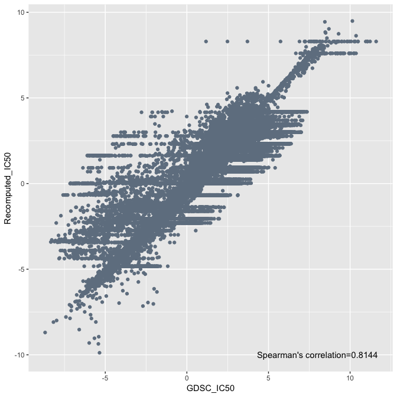

```r
data("Conventional_GR_allCalculatedMetrics_merged",package = "AlternativeDrugResponseMetrics")
data("GDSC_orig_IC50_AUC",package = "AlternativeDrugResponseMetrics")
colnames(GDSC_orig_IC50_AUC)<-c("CellLine","Drug","GDSC_LNIC50","GDSC_AUC")

#Rescale the recomputed AUCs to match with the ranges of GDSC AUCs (0 -1)
Max_AUC<-max(Conventional_GR_allCalculatedMetrics_merged$AUC)
Min_AUC<-min(Conventional_GR_allCalculatedMetrics_merged$AUC)
Rescaled_AUC<-sapply(Conventional_GR_allCalculatedMetrics_merged$AUC, function(x) (x-Min_AUC)/(Max_AUC-Min_AUC))
Conventional_GR_allCalculatedMetrics_merged<-cbind.data.frame(Conventional_GR_allCalculatedMetrics_merged,Rescaled_AUC)

#Merge the IC50s/AUCs from GDSC and the values calculated using "drc" package
GDSC_RecomputedIC50s_merged<-merge(Conventional_GR_allCalculatedMetrics_merged,GDSC_orig_IC50_AUC,by=c("CellLine","Drug"))

#Plot GDSC IC50s vs Calculated IC50s
#jpeg(filename="GDSC_Recomputed_IC50_correlation_plots.jpeg")
par(cex=1,mar=c(4,4,2,1),cex.lab=1,cex=1.5,font=2)
correlation<-cor(GDSC_RecomputedIC50s_merged$GDSC_LNIC50,GDSC_RecomputedIC50s_merged$LN_IC50,method = "spearman")
ggplot(GDSC_RecomputedIC50s_merged,aes(x=GDSC_LNIC50,y=LN_IC50))+geom_point(color="slategray")+xlab("GDSC_IC50")+ylab("Recomputed_IC50")+annotate(geom="text",label=paste("Spearman's correlation=",round(correlation,digits=4),sep=""),x=8,y=-10,color="black")
```

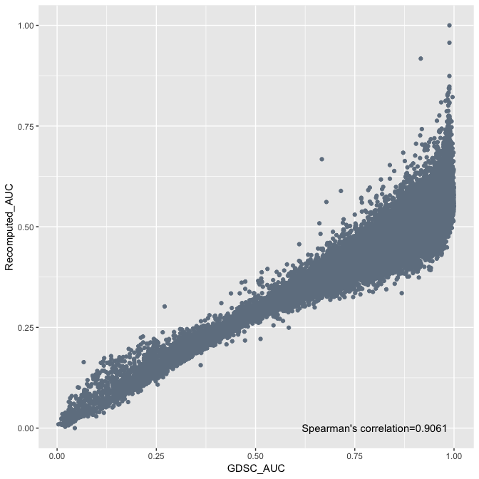

```r
#dev.off()

#Plot GDSC AUC vs Calculated AUCs
#jpeg(filename="GDSC_Recomputed_AUC_correlation_plots_rescaledAUCs.jpeg")
par(cex=1,mar=c(4,4,2,1),cex.lab=1,cex=1.5,font=2)
correlation<-cor(GDSC_RecomputedIC50s_merged$GDSC_AUC,GDSC_RecomputedIC50s_merged$Rescaled_AUC,method = "spearman")
ggplot(GDSC_RecomputedIC50s_merged,aes(x=GDSC_AUC,y=Rescaled_AUC))+geom_point(color="slategray")+xlab("GDSC_AUC")+ylab("Recomputed_AUC")+annotate(geom="text",label=paste("Spearman's correlation=",round(correlation,digits=4),sep=""),x=0.80,y=0,color="black")
```

```r
#dev.off()
```

Compute Drug-wise correlations for the IC50s and AUCs obtained by different curve-fitting procedures (Figures 17 and 18)

```r
AllCor<-c()

UniqueDrugs<-unique(as.vector(GDSC_RecomputedIC50s_merged$Drug))
for(i in 1:length(UniqueDrugs))
{
  Drug_extract<-GDSC_RecomputedIC50s_merged[GDSC_RecomputedIC50s_merged$Drug==UniqueDrugs[i],]
  Cor_drug_AUC<-cor(Drug_extract$Rescaled_AUC,Drug_extract$GDSC_AUC,method="spearman")
  Cor_drug_IC50<-cor(Drug_extract$LN_IC50,Drug_extract$GDSC_LNIC50,method="spearman")

  #Pick those cell lines, for which Emax<0.1 or Emax>0.8
  Strong_narrowRange<-length(which(Drug_extract$Emax < 0.1))
  Weak_narrowRange<-length(which(Drug_extract$Emax >0.8))

  cor_drug_merged<-cbind.data.frame(Drug=UniqueDrugs[i],Datapoints=nrow(Drug_extract),Corr_AUC=Cor_drug_AUC,Corr_IC50=Cor_drug_IC50,Strong_range=(Strong_narrowRange/nrow(Drug_extract))*100,Weak_range= (Weak_narrowRange/nrow(Drug_extract))*100)
  AllCor<-rbind.data.frame(AllCor,cor_drug_merged)
}



```

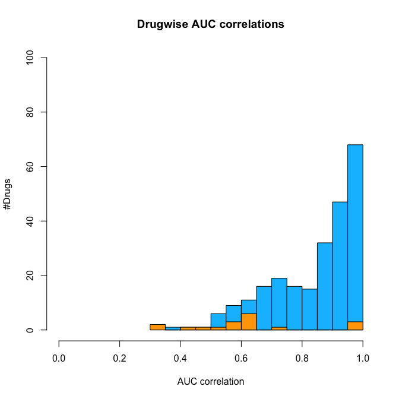

```r
AllCor_complete<-AllCor[complete.cases(AllCor),]
write.table(AllCor_complete,file="Drugwise_RescaledAUC_IC50_Origcorr.txt",sep="\t",row.names=FALSE,quote=FALSE)

#Extract those drugs which are either too responsive or unreponsive to 90% of the cell lines
Narrow_Dist<-subset(AllCor_complete,(AllCor_complete$Strong_range>90 | AllCor_complete$Weak_range>90))
Uniform_Dist<-AllCor_complete[!(AllCor_complete$Drug %in% Narrow_Dist$Drug),]

#jpeg(filename="DrugwiseRescaledAUC_correlation_histograms_dist_sep.jpeg")
hist(Uniform_Dist$Corr_AUC,breaks=10,xlim=c(0,1),ylim=c(0,100),col="deepskyblue",main='Drugwise AUC correlations',xlab='AUC correlation',ylab='#Drugs')
hist(Narrow_Dist$Corr_AUC,breaks=10,xlim=c(0,1),ylim=c(0,100),col="orange",main='Drugwise AUC correlations',xlab='AUC correlation',ylab='#Drugs',add=T)
```

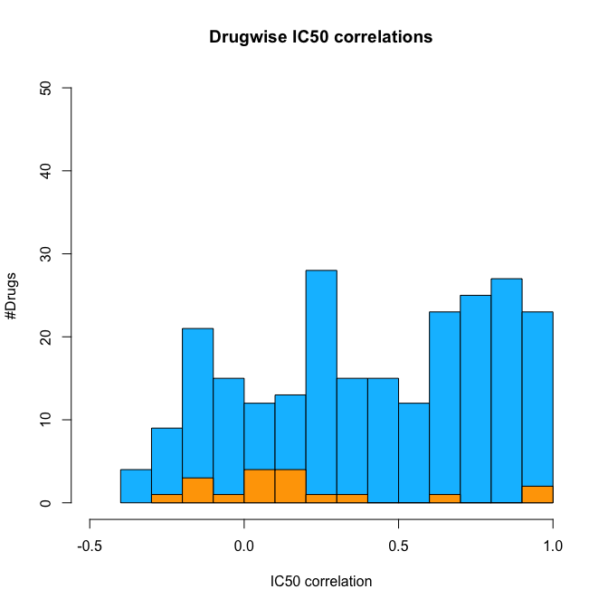

```r
#dev.off()

#jpeg(filename="DrugwiseIC50_correlation_histograms_dist_sep.jpeg")
hist(Uniform_Dist$Corr_IC50,breaks=10,xlim=c(-0.5,1),ylim=c(0,50),col="deepskyblue",main='Drugwise IC50 correlations',xlab='IC50 correlation',ylab='#Drugs')
hist(Narrow_Dist$Corr_IC50,breaks=10,xlim=c(-0.5,1),ylim=c(0,50),col="orange",main='Drugwise IC50 correlations',xlab='IC50 correlation',ylab='#Drugs',add=T)
```

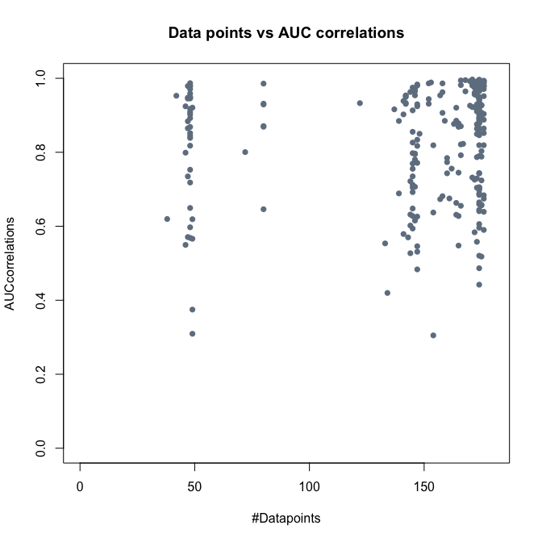

```r
#dev.off()

#jpeg(filename="DataPoints_RescaledAUC_Correlations.jpeg")
plot(AllCor_complete$Datapoints,AllCor_complete$Corr_AUC,pch=16,xlim=c(0,180),ylim=c(0,1),col="slategrey",main='Data points vs AUC correlations',xlab='#Datapoints',ylab='AUCcorrelations')
```

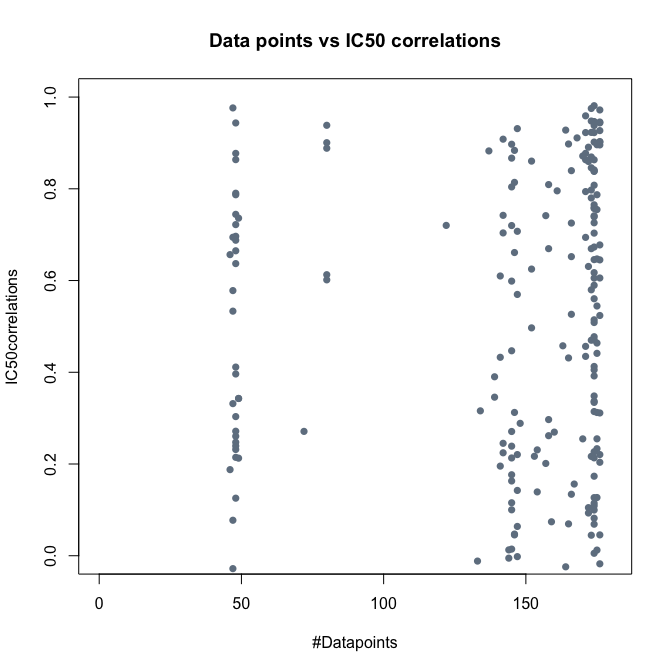

```r
#dev.off()

#jpeg(filename="DataPoints_IC50_Correlations.jpeg")
plot(AllCor_complete$Datapoints,AllCor_complete$Corr_IC50,pch=16,xlim=c(0,180),ylim=c(0,1),col="slategrey",main='Data points vs IC50 correlations',xlab='#Datapoints',ylab='IC50correlations')
```

```r
#dev.off()
```